# Exploring ECC counter data

Diarmuid Lloyd

Last run: 2021-10-26

# Introduction

Loading counter data for locations John flagged as of interest:

**On Road - Non SfP**

- 052 A8 Wester Coates

**Off Road - Non SfP**

- 015 Middle Meadow Walk

#Connecting to database

```r
con <- DBI::dbConnect(RSQLite::SQLite(), dbname = "data/ecc-counter-database-output.sqlite")

df <- tbl(con, "station_counts_hour_joined") %>%
  filter(station_num %in% c("31","35","48","38","52","15")) %>% collect()

dbDisconnect(con)


con2 <- DBI::dbConnect(RSQLite::SQLite(), dbname = "data/cycle-hire.db")

df2 <- tbl(con2, "trips") %>%  collect()

dbDisconnect(con2)
```

# Intial plots and exploring data

Checking how many records there are per station, per direction for each hourly time period. Would only expect there to be one for each.

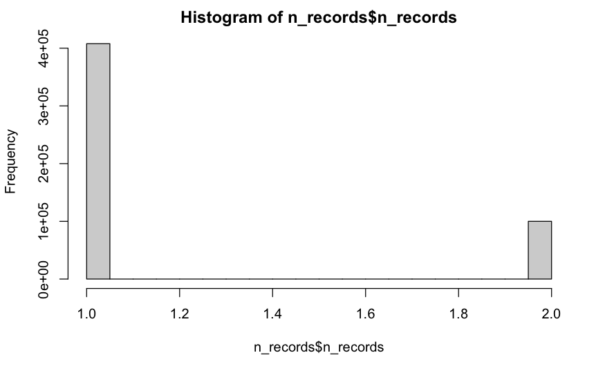

Most have one record, but a significant number have two. Is there something different about the stations with two records?

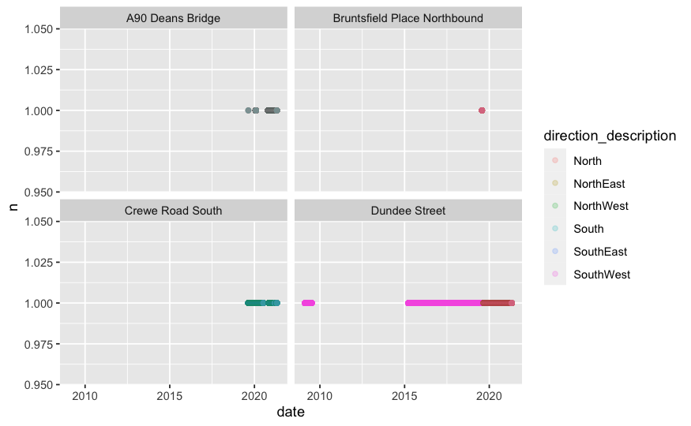

```r
n_records %>%
  group_by(station_name,date, direction_description) %>%
  filter(n_records > 1) %>%
  summarise(n = n()) %>%
  ggplot() +
  geom_point(aes(x = date, y = n, colour = direction_description),alpha = 0.2) +
  facet_wrap(~station_name)
```

[output not shown]

```r
df <- df %>% mutate(date = lubridate::as_datetime(date))

df %>% count(station_name)
```

| station_num | station_name | n |
| --- | --- | --- |
| 15 | Middle Meadow Walk | 129122 |
| 31 | Dundee Street | 134692 |
| 35 | A90 Deans Bridge | 76556 |
| 38 | Bruntsfield Place Northbound | 92468 |
| 48 | Crewe Road South | 113772 |
| 52 | A8 Wester Coates | 61278 |

```r
df %>% count(flag_text)
```

| station_num | flag_text | n |
| --- | --- | --- |
| 15 | Bad data | 602 |
| 15 | Run of Zeroes | 6264 |
| 15 | NA | 122256 |
| 31 | Holiday | 1248 |
| 31 | Special | 10560 |
| 31 | Special,Holiday | 384 |
| 31 | NA | 122500 |
| 35 | Holiday | 672 |
| 35 | NA | 75884 |
| 38 | Bad data | 240 |

[output cut: 12 more lines]

```r
df <- df %>%
  group_by(station_num) %>%
  mutate(week_starting = lubridate::floor_date(date, unit = "week") %>% as.Date(),
         year = lubridate::year(date),
         month_starting = lubridate::floor_date(date, unit = "month") %>% as.Date())

df_weekly <- df %>%
  group_by(station_name,week_starting) %>%
  filter(is.na(flag_text)) %>%
  summarise(volume = sum(volume))
df_monthly <- df %>%
  group_by(station_name,month_starting) %>%
  filter(is.na(flag_text)) %>%
  summarise(volume = sum(volume))
```

Plotting raw volume by hour

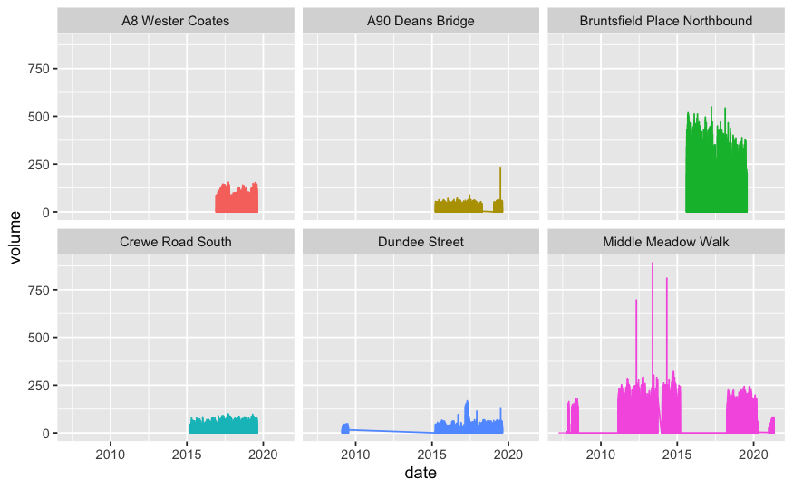

```r
ggplot(df) +
  geom_line(aes(x = date, y = volume, group = station_num,colour = station_name)) +
  facet_wrap(~station_name) +
  theme(legend.position = "none")
```

## Filtered out bad data

Plotting weekly total trips, also filtering out all flagged “bad data”. Seems to knock out Pedal on Parliament on MMW (guessed this is what the peaks are)? Regardless, huge gaps in the data.

[figure not shown]

Plotting monthly total trips, again bad data filtered out, but also clipping to 2019 onward:

```r
monthly_counts_rough <- ggplot(df_monthly) +
  geom_col(aes(month_starting, volume, fill = station_name)) +
  facet_wrap(~station_name) +
    theme(legend.position = "none") +
  scale_x_date(limits = c(as.Date("2019-01-01"),as.Date("2022-01-01")),
               name = "Monthly counts")

monthly_counts_rough
png("output/rough_monthly_counts.png", width = 30, height = 20, units = "cm", res = 300 )
```

[figure not shown]

```r
monthly_counts_rough
dev.off()
```